# Metagenome Analysis

Only ancestral, streptomycin and control treatments are included, unless otherwise stated.

Authors

Niina Smolander

Shane Hogle

# Libraries and functions

Prior to this analysis, the variants have been filtered using Mutect2’s FilterMutectCalls as well as separately for SNPs and INDELs using the following hard filtering factors: SOR, FS, MQ, MQRankSum, ReadPosRankSum, SNP/INDEL clustering (3/35) and SNP/INDEL proximity.

```r
library(tidyverse)
library(Polychrome)
library(withr)
library(fs)
library(compositions)
library(vegan)
library(qvalue)

source("data/input/utils_parallelism.R")
```

# 1) Barplot of mutation distributions (parellelism at nucleotide level)

Looking into how many mutations are found in how many replicates in different HAMBIs at any timepoint. Using https://slhogle.github.io/hambiDoubleEvo/R/metagenome/02_parallelism.html as reference, but fixed variants (VAF = 1) seen in the timepoint 0 are not excluded.

```r
variants_strep <- read_rds("data/input/variants_strep.rds")

chrom_lengths <- read_tsv("data/input/chrom_lengths.tsv")

# exclude fixed variants from timepoint 0
# tofilter <- variants_strep %>%
#   filter(Timepoint == "t0") %>%
#   filter(VAF == 1) %>%
#   dplyr::select(CHROM, POS, REF, ALT, Home) %>%
#   distinct()


# variants_filt <- anti_join(variants_strep, tofilter, by = join_by(CHROM, POS, REF, ALT, Home)) %>%
#   filter(Timepoint != "t0")

# HAMBI_mutations_filt <- variants_strep %>%
#   group_by(HAMBI, Measure, Home, CHROM, POS, REF, ALT) %>%
#   mutate(mi=n_distinct(Replicate)) %>% ungroup() %>%
#   group_by(HAMBI) %>%
#   count(mi) %>% ungroup() %>%
#   group_by(mi) %>%
#   mutate(tot = sum(n)) %>%
#   arrange(desc(mi)) %>% ungroup()

HAMBI_mutations_filt2 <- variants_strep %>%
  group_by(HAMBI, Measure, Home, CHROM, POS, REF, ALT) %>%
  mutate(mi=n_distinct(Replicate)) %>% ungroup() %>%
  group_by(HAMBI, Home, Measure) %>%
  count(mi) %>% ungroup() %>%
  group_by(mi) %>%
  mutate(tot = sum(n)) %>%
  arrange(desc(mi)) %>% ungroup()
```

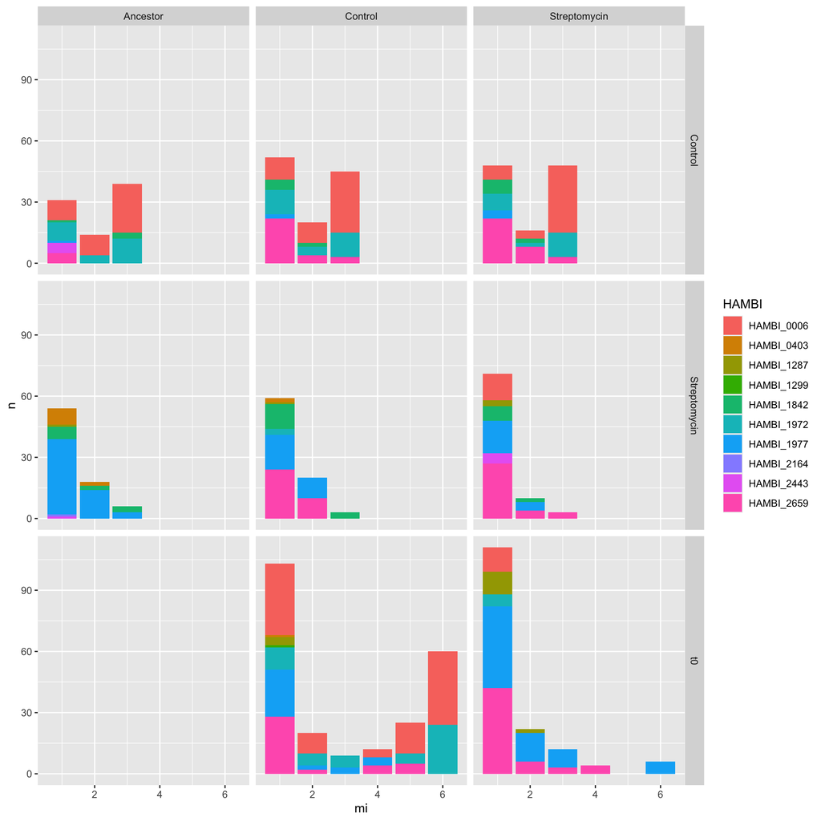

```r
HAMBI_mutations_filt2 %>%
  ggplot(aes(x = mi, y = n, fill = HAMBI)) +
  geom_bar(stat = "identity") +
  facet_grid(Measure ~ Home)
```

# 2) Parallelism at gene level

If there were no selection pressure or differences in mutation rates between genes, the number of mutations in each gene should be proportional to gene size. Hence, we can calculate the expected number of nonsynonymous mutations and compare the expected and observed. Between expected and observed G-scores (goodness of fit) are computed and their significance is assessed using permutation tests. Finally, we find the enriched genes for all of the home-measurement environment combinations. Reference and full explanation can be found at: https://slhogle.github.io/hambiDoubleEvo/R/metagenome/02_parallelism.html

```r
degentab <- read_rds("data/input/annotations_codon_degeneracy.rds")

mgvars_filt_mb_ns <- variants_strep %>%
  # exclude intragenic, intergenic, and synonymous mutations. Also exclude
  # fusion functions because these are weird and also rare. Excluding the
  # modifier category also ensures that we filter out any tRNAs with mutations
  filter(!str_detect(EFFECT, "intergenic|intragenic|synonymous|fusion")) %>%
  filter(!str_detect(IMPACT, "MODIFIER"))

muts_by_sp_treat <- mgvars_filt_mb_ns %>%
  dplyr::rename(strainID = HAMBI,
                locus_tag = GENE) %>%
  dplyr::select(-c(VAF, Timepoint)) %>%
  group_by(strainID, Home, Measure) %>%
  distinct() %>%
  mutate(groupid = cur_group_id()) %>%
  group_by(groupid, strainID, Home, Measure)


# doing 10000 permutations
#result_sp_treat <- run_full_gene_parallelism_pipeline(muts_by_sp_treat, degentab, 10000)

# Save this for later (saved!)
#write_rds(result_sp_treat, "data/results/annotations_codon_degeneracy_incl_t0.rds")

result_sp_treat <- read_rds("data/results/annotations_codon_degeneracy_incl_t0.rds")

#plot of null and observed
# result_sp_treat$output_simulated_reps %>%
#   ggplot(aes(x = n_reps, y = n, fill = type)) +
#   geom_bar(position = "dodge", stat = "identity") +
#   facet_wrap(Home+strainID ~ Measure) +
#   theme(axis.text.x = element_text(angle = 90, vjust = 0.5, hjust=1))
```

## 2.1) Survival curve plot

Blue line: observed number of genes, Grey line: expected number of genes, Red line: genome-wide significance threshold.

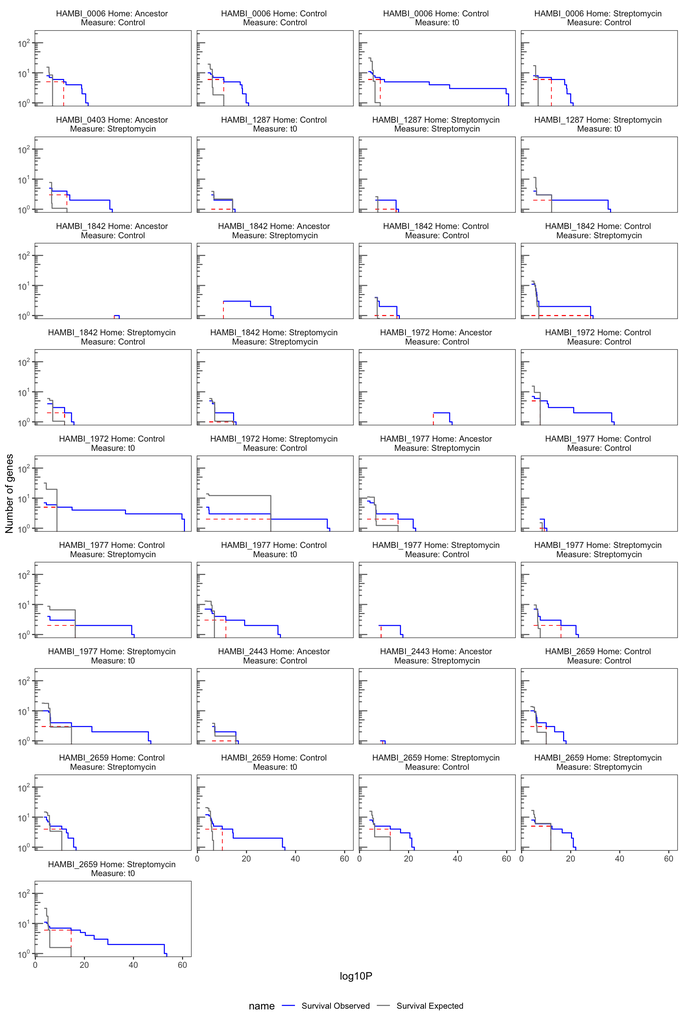

```r
result_sp_treat$output_df2plot %>%
  filter(!is.na(xend)) %>%
  mutate(label = paste(strainID, "Home:", Home, "\nMeasure:", Measure)) %>%
  ggplot() +
    geom_segment(
      aes(
        x = x,
        y = y,
        xend = xend,
        yend = yend
      ),
      linetype = "dashed",
      linewidth = 0.25, color = "red"
    ) +
    geom_step( aes(x = obs_p, y = value, color = name)) +
    facet_wrap(~ label, ncol = 4) +
    labs(x = "log10P", y = "Number of genes") +
    scale_color_manual(values = c("blue", "grey50")) +
    scale_y_log10(
      breaks = c(1, 10, 100),
      labels = scales::trans_format("log10", scales::math_format(10 ^.x))
    ) +
    annotation_logticks(sides = "l", color = "grey40") +
    coord_cartesian(ylim = c(1, 200)) +
    theme_bw() +
    theme(
      strip.background = element_blank(),
      panel.grid = element_blank(),
      legend.position = "bottom"
    )
```

## 2.2) Significant G scores

```r
t <- result_sp_treat$output_gscore %>%
  filter(pvalue <= 0.05)

knitr::kable(t)
```

| groupid | observed_g_score | pvalue | strainID | Home | Measure |
| --- | --- | --- | --- | --- | --- |
| 1 | 6.658866 | 0.0000 | HAMBI_0006 | Ancestor | Control |
| 2 | 6.280859 | 0.0000 | HAMBI_0006 | Control | Control |
| 3 | 6.368322 | 0.0000 | HAMBI_0006 | Control | t0 |
| 4 | 6.567938 | 0.0000 | HAMBI_0006 | Streptomycin | Control |
| 7 | 7.446201 | 0.0000 | HAMBI_0403 | Ancestor | Streptomycin |
| 8 | 8.409097 | 0.0492 | HAMBI_0403 | Control | Streptomycin |
| 13 | 7.266815 | 0.0000 | HAMBI_1287 | Streptomycin | t0 |
| 15 | 8.876788 | 0.0000 | HAMBI_1842 | Ancestor | Control |
| 16 | 7.518061 | 0.0000 | HAMBI_1842 | Ancestor | Streptomycin |
| 17 | 7.698125 | 0.0006 | HAMBI_1842 | Control | Control |
| 18 | 6.429209 | 0.0000 | HAMBI_1842 | Control | Streptomycin |
| 21 | 7.025552 | 0.0000 | HAMBI_1972 | Ancestor | Control |
| 22 | 6.509704 | 0.0000 | HAMBI_1972 | Control | Control |
| 24 | 6.396884 | 0.0000 | HAMBI_1972 | Control | t0 |
| 25 | 6.327163 | 0.0000 | HAMBI_1972 | Streptomycin | Control |
| 27 | 6.758282 | 0.0003 | HAMBI_1977 | Ancestor | Streptomycin |
| 28 | 8.836713 | 0.0103 | HAMBI_1977 | Control | Control |
| 29 | 7.926151 | 0.0000 | HAMBI_1977 | Control | Streptomycin |
| 30 | 6.972766 | 0.0000 | HAMBI_1977 | Control | t0 |
| 31 | 8.729127 | 0.0000 | HAMBI_1977 | Streptomycin | Control |
| 32 | 7.391594 | 0.0000 | HAMBI_1977 | Streptomycin | Streptomycin |
| 33 | 7.075462 | 0.0000 | HAMBI_1977 | Streptomycin | t0 |
| 35 | 7.623093 | 0.0166 | HAMBI_2443 | Ancestor | Control |
| 36 | 9.438673 | 0.0426 | HAMBI_2443 | Ancestor | Streptomycin |
| 39 | 5.974183 | 0.0129 | HAMBI_2659 | Control | Control |
| 41 | 5.925212 | 0.0000 | HAMBI_2659 | Control | t0 |
| 42 | 6.208508 | 0.0000 | HAMBI_2659 | Streptomycin | Control |
| 43 | 6.168692 | 0.0000 | HAMBI_2659 | Streptomycin | Streptomycin |
| 44 | 5.983068 | 0.0000 | HAMBI_2659 | Streptomycin | t0 |

## 2.3) Inspecting individual genes

Filtering out the genes with a too large a number of consecutive mutations and are unlikely to be real mutations.

```r
high_density_genes <- mgvars_filt_mb_ns %>%
  group_by(HAMBI, GENE, replicate, Home, Measure) %>%
  mutate(mutwindox = POS - lag(POS),
         mut_num = n(),
         mut_dens = n()/(max(POS) -  min(POS))) %>%
  ungroup() %>%
  filter(mut_dens != Inf) %>%
  filter(mut_dens > 0.15) %>%
  distinct(GENE) %>%
  pull()

output_gene_table_filt <- result_sp_treat$output_gene_table %>%
  # only genes exceeding the critical pstar value from the survival curves above
  filter(neg_log10P >= pstar) %>%
  # only include genes with at least 3 hits in the same gene or found in more than one replicate.
  filter(observed_hits_n_i >= 3 | n_replicate > 1) %>%
  # filters out the problematic genes above unless the number of replicates detected is 2 or more
  filter(case_when(n_replicate < 2 ~ !(locus_tag %in% high_density_genes),
                   TRUE ~ n_replicate > 1)) %>%
  left_join(degentab, by = join_by(locus_tag, strainID)) %>%
  arrange(locus_tag)

# add some annotation
eggnog <- read_tsv("data/input/HAMBI_all_eggnog_formatted.tsv.xz")

output_gene_table_filt_cog <- left_join(output_gene_table_filt, eggnog) %>%
  rename(prokka_annotation = product) %>%
  relocate(strainID, Home, Measure, COG_category_long, Preferred_name, Description, prokka_annotation)

#write_tsv(output_gene_table_filt_cog, "data/results/parallel_genes_incl_t0.tsv")
```

```r
rmarkdown::paged_table(output_gene_table_filt)
```

| groupid | locus_tag | neg_log10P | strainID | pstar | nonsyn_sites | observed_hits_n_i | n_replicate | gene_multiplicity_m_i | A | B | C | D | E | F | Home | Measure | chrom | feature_type | start | end | strand | cds_length | ns_length | f0 | f2 | f3 | f4 | gene | product | … |
| --- | --- | --- | --- | --- | --- | --- | --- | --- | --- | --- | --- | --- | --- | --- | --- | --- | --- | --- | --- | --- | --- | --- | --- | --- | --- | --- | --- | --- | --- | --- |
| 1 | H0006_00502 | 19.026761 | HAMBI_0006 | 11.536474 | 946 | 3 | 3 | 2.5174513 | 1 | 1 | 1 | NA | NA | NA | Ancestor | Control | HAMBI_0006_chrm01_circ | CDS | 582461 | 583603 | + | 1143 | 946 | 735 | 198 | 13 | 197 | birA | Bifunctional ligase/repressor BirA | … |
| 2 | H0006_00502 | 18.357931 | HAMBI_0006 | 10.734151 | 946 | 3 | 3 | 2.5174513 | 1 | 1 | 1 | NA | NA | NA | Control | Control | HAMBI_0006_chrm01_circ | CDS | 582461 | 583603 | + | 1143 | 946 | 735 | 198 | 13 | 197 | birA | Bifunctional ligase/repressor BirA | … |
| 3 | H0006_00502 | 59.762651 | HAMBI_0006 | 8.436040 | 946 | 6 | 6 | 5.0349025 | 1 | 1 | 1 | 1 | 1 | 1 | Control | t0 | HAMBI_0006_chrm01_circ | CDS | 582461 | 583603 | + | 1143 | 946 | 735 | 198 | 13 | 197 | birA | Bifunctional ligase/repressor BirA | … |
| 4 | H0006_00502 | 18.511661 | HAMBI_0006 | 12.157847 | 946 | 3 | 3 | 2.5174513 | 1 | 1 | 1 | NA | NA | NA | Streptomycin | Control | HAMBI_0006_chrm01_circ | CDS | 582461 | 583603 | + | 1143 | 946 | 735 | 198 | 13 | 197 | birA | Bifunctional ligase/repressor BirA | … |
| 1 | H0006_02725 | 11.536474 | HAMBI_0006 | 11.536474 | 1308 | 2 | 2 | 1.2138170 | 1 | 0 | 1 | NA | NA | NA | Ancestor | Control | HAMBI_0006_chrm01_circ | CDS | 3026200 | 3027846 | + | 1647 | 1308 | 1035 | 260 | 13 | 339 | NA | hypothetical protein | … |
| 3 | H0006_02725 | 28.430328 | HAMBI_0006 | 8.436040 | 1308 | 5 | 5 | 3.0345424 | 1 | 1 | 1 | 0 | 1 | 1 | Control | t0 | HAMBI_0006_chrm01_circ | CDS | 3026200 | 3027846 | + | 1647 | 1308 | 1035 | 260 | 13 | 339 | NA | hypothetical protein | … |
| 4 | H0006_02725 | 17.540716 | HAMBI_0006 | 12.157847 | 1308 | 3 | 3 | 1.8207255 | 1 | 1 | 1 | NA | NA | NA | Streptomycin | Control | HAMBI_0006_chrm01_circ | CDS | 3026200 | 3027846 | + | 1647 | 1308 | 1035 | 260 | 13 | 339 | NA | hypothetical protein | … |
| 1 | H0006_03238 | 20.519437 | HAMBI_0006 | 11.536474 | 575 | 3 | 3 | 4.1417546 | 1 | 1 | 1 | NA | NA | NA | Ancestor | Control | HAMBI_0006_chrm01_circ | CDS | 3598207 | 3598902 | + | 696 | 575 | 448 | 114 | 13 | 121 | glaR_2 | HTH-type transcriptional repressor GlaR | … |
| 2 | H0006_03238 | 19.850372 | HAMBI_0006 | 10.734151 | 575 | 3 | 3 | 4.1417546 | 1 | 1 | 1 | NA | NA | NA | Control | Control | HAMBI_0006_chrm01_circ | CDS | 3598207 | 3598902 | + | 696 | 575 | 448 | 114 | 13 | 121 | glaR_2 | HTH-type transcriptional repressor GlaR | … |
| 3 | H0006_03238 | 59.762651 | HAMBI_0006 | 8.436040 | 575 | 6 | 6 | 8.2835092 | 1 | 1 | 1 | 1 | 1 | 1 | Control | t0 | HAMBI_0006_chrm01_circ | CDS | 3598207 | 3598902 | + | 696 | 575 | 448 | 114 | 13 | 121 | glaR_2 | HTH-type transcriptional repressor GlaR | … |

[output cut: 75 more lines]